# 尺規作圖的工具與等線段、等角

> 來源整理：改國二下3_尺規作圖_易讀版.md

## 尺規作圖的工具與限制

> 學習目標：尺規作圖不是量一量就好，而是只用無刻度直尺畫直線、用圓規保留距離。

### 先抓住核心

- 無刻度直尺只能連接兩點或延長直線，不能拿來量長度。
- 圓規可以複製距離，也可以用指定點當圓心畫圓弧。
- 作圖的重點是讓圖形由『相等距離』與『交點』自然決定，而不是靠目測。
- 題目常分成已知、求作、作法、理由；讀題時先找已知圖形和最後要畫出的圖形。
- 所有作圖都要保留輔助弧與交點，這些痕跡就是你的作圖理由。

### 作圖流程

1. 看已知：找出題目給的點、線、角或線段。
2. 看求作：確認要畫的是等長線段、等角、垂線、平行線，還是平分線。
3. 用圓規複製距離，用直尺連接交點。
4. 最後用性質驗證：等距、垂直、平行、角相等或中點。

### 公式、性質與判斷

- **直尺**：只能畫直線，不能量長度。
- **圓規**：用來複製距離與畫圓弧。
- **作圖理由**：交點來自相同半徑，常可推出等邊、等腰、菱形或中垂線。

### 例題拆解

- 要複製一段長度 a，不是用尺量 a 公分，而是用圓規張開成 a，再移到新的位置。
- 要畫垂線，常先用圓規做出兩個等距點，再連接兩個弧交點。
- 若圖上有兩個圓弧交點，通常表示它們到兩個圓心的距離相等。

### 易錯提醒

- 偷偷用刻度量長度，雖然畫得出來，但不算尺規作圖。
- 只畫最後答案、不保留弧線與交點，會讓作圖理由消失。

### 小練一下

- 尺規作圖中的直尺可以量長度嗎？
- 圓規在作圖中最重要的功能是什麼？

### 記憶鉤子

- 直尺負責『直』，圓規負責『等距』。
- 作圖題不是畫得像，而是每一步都能說出為什麼。

### 圖像化理解

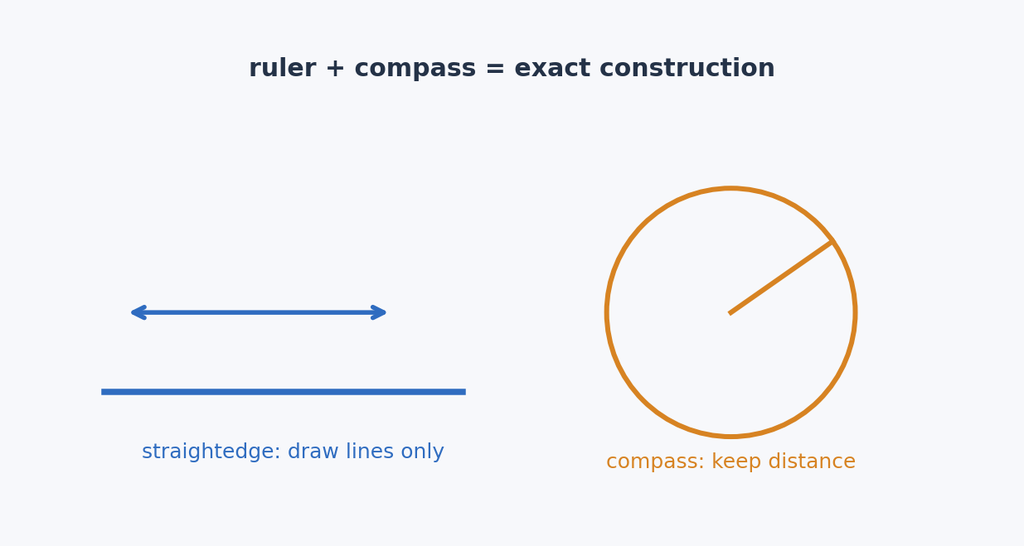

尺規作圖的工具與限制

圖解：用直尺與圓規功能對照，建立本章的作圖規則。

## 等線段作圖

> 學習目標：等線段作圖就是把已知長度搬到一條新射線上。

### 先抓住核心

- 已知一段長度 a，要在新位置畫出同樣長的線段。
- 先畫一條射線或直線，選定端點 A。
- 圓規張開到已知線段 a 的長度，不改變圓規開口。
- 以 A 為圓心畫弧，弧與射線交於 B，則 AB = a。
- 這個方法是後面線段和、線段差、作三角形的基礎。

### 作圖流程

1. 畫射線 L，取端點 A。
2. 圓規量取已知線段 a。
3. 以 A 為圓心、a 為半徑畫弧交 L 於 B。
4. 得到線段 AB，且 AB = a。

### 公式、性質與判斷

- **等線段**：用同一個圓規開口搬移長度。
- **結論**：AB = a。

### 例題拆解

- 已知線段 a，若以 A 為圓心、a 為半徑畫弧交射線於 B，則 AB 就等於 a。
- 若要再複製一次同長度，可不改變圓規開口，從 B 再畫一次。

### 易錯提醒

- 畫弧前改變圓規開口，導致新線段不等於原線段。
- 忘記先決定端點 A，作出來的線段位置不清楚。

### 小練一下

- 等線段作圖最後要得到哪兩個長度相等？
- 圓規量好 a 之後，可以任意改變開口嗎？

### 記憶鉤子

- 等線段作圖的靈魂是『圓上每一點到圓心距離都等於半徑』。
- 只要圓規開口沒變，搬到哪裡都是同一段長度。

### 圖像化理解

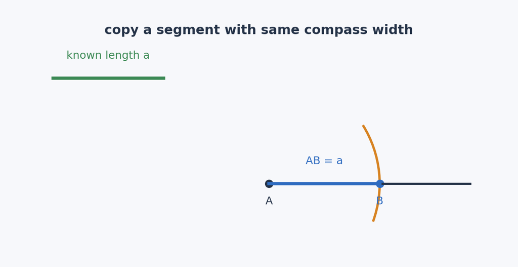

等線段作圖

圖解：用圓規把已知長度 a 搬到射線上，得到 AB = a。

## 線段和與線段差

> 學習目標：線段和是沿同一方向接上去，線段差是在同一條線上從大段扣掉小段。

### 先抓住核心

- 要作 a+b，先作出 AB = a，再從 B 往同方向作 BC = b，得到 AC = a+b。
- 要作 a-b，通常先作 AB = a，再從 A 或 B 量出 b，留下差的那一段。
- 線段和與差都靠等線段作圖反覆搬移距離。
- 作差時要先確認 a 大於 b，否則線段差的方向或結果會不符合題意。
- 圖上要標清楚 A、B、C 的順序，才知道答案是哪一段。

### 作圖流程

1. 線段和：作射線，先取 AB = a。
2. 線段和：以 B 為圓心取 BC = b，則 AC = a+b。
3. 線段差：先取 AB = a。
4. 線段差：在 AB 上取 AC = b，則 CB = a-b。

### 公式、性質與判斷

- **線段和**：AB = a, BC = b, AC = a+b。
- **線段差**：AB = a, AC = b, CB = a-b。

### 例題拆解

- 若 a = 7、b = 3，作線段和會得到 10；作線段差會得到 4。
- 在作 a+b 時，b 要接在 a 的末端，不要回頭畫。
- 在作 a-b 時，b 要放在 a 的同一條線段上，剩下的部分才是差。

### 易錯提醒

- 作 a+b 時把 b 畫到反方向，結果變成差或位置錯誤。
- 作 a-b 時沒有確定 C 在 AB 上，導致答案不是剩下的線段。

### 小練一下

- 若 AB = a、BC = b 且 A、B、C 共線依序排列，AC 是多少？
- 若 AB = a、AC = b，且 C 在 AB 上，CB 是多少？

### 記憶鉤子

- 加法看『接上去』，減法看『拿掉一段』。
- 作圖題裡的線段運算，其實就是長度的搬移與排列。

### 圖像化理解

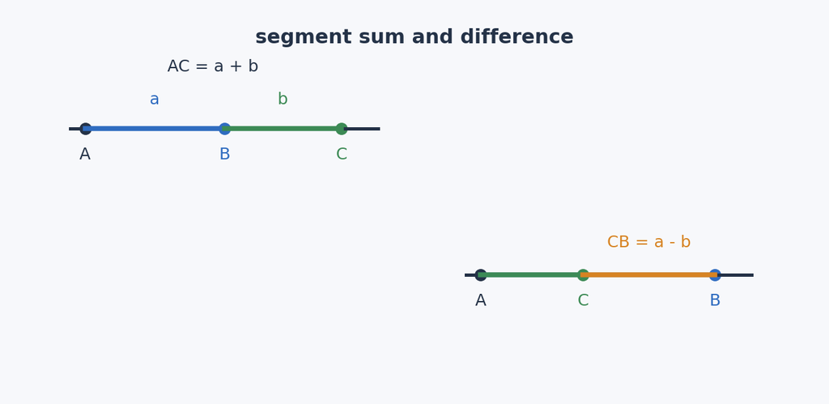

線段和與線段差

圖解：同一張圖對照 a+b 與 a-b，讓線段運算的方向更清楚。

## 等角作圖

> 學習目標：等角作圖是把已知角的開口大小搬到新的頂點上。

### 先抓住核心

- 先在已知角上，以頂點 O 為圓心畫弧，交兩邊於 D、E。
- 在新位置先畫一條射線，以新頂點 A 為圓心，用相同半徑畫弧。
- 圓規量取已知角弧上兩交點 D、E 的距離。
- 在新弧上截出同樣的弦長，得到點 C。
- 連接 A、C，新角就和原角相等。

### 作圖流程

1. 在原角畫弧，得到兩個交點 D、E。
2. 在新頂點 A 畫同半徑弧，先得到 B。
3. 用圓規量 DE，在新弧上從 B 截出 C。
4. 連 AC，得到和原角相等的新角。

### 公式、性質與判斷

- **等角**：同半徑、同弦長會對應同角度。
- **結論**：新角 = 原角。

### 例題拆解

- 若原角是 40 度，依等角作圖得到的新角也是 40 度。
- 等角作圖不需要量角器，靠的是同半徑圓弧與同弦長。

### 易錯提醒

- 只畫同半徑弧，卻沒有複製弦長 DE，角度仍不一定相等。
- 把原角和新角的頂點混淆，導致連錯線。

### 小練一下

- 等角作圖中，為什麼要量弧上兩交點的距離？
- 新角的頂點是原來的 O，還是新選的 A？

### 記憶鉤子

- 等角作圖可以想成『複製一個扇形的開口』。
- 同半徑加同弦長，角度就被固定住。

### 圖像化理解

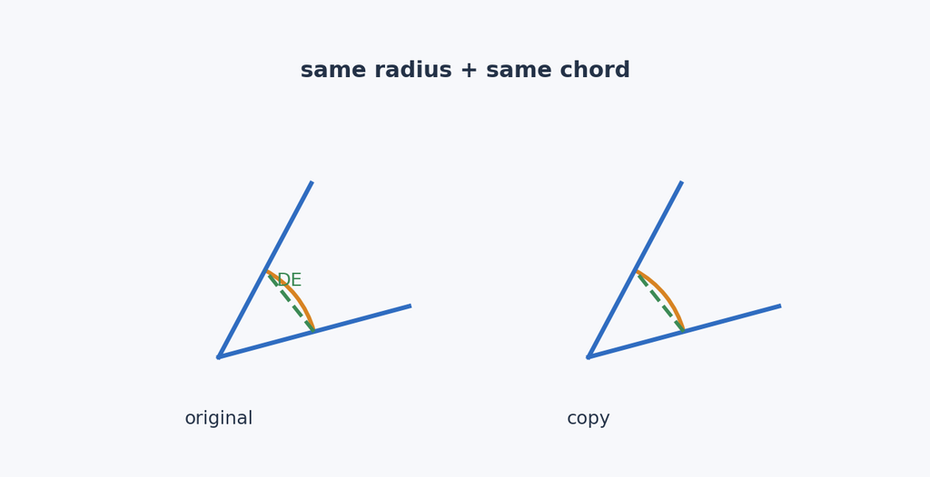

等角作圖

圖解：用兩個同半徑圓弧與同弦長，示意如何複製角度。

## 兩角和與兩角差

> 學習目標：角的加減，就是把等角作圖放在同一個頂點上，決定第二個角放在哪一側。

### 先抓住核心

- 作兩角和時，先複製第一個角，再從它的邊上接著複製第二個角。
- 作兩角差時，先複製較大的角，再在它內部複製較小的角，剩下部分就是差。
- 角加減的關鍵是共用同一個頂點。
- 作圖時要清楚標出哪條射線是第一個角的終邊，哪條是第二個角的終邊。
- 兩角差要先確認哪個角比較大，否則會出現方向錯誤。

### 作圖流程

1. 兩角和：在新頂點先作出角 A。
2. 兩角和：以角 A 的終邊為起邊，再作出角 B。
3. 兩角差：先作大角。
4. 兩角差：在大角內部作小角，剩下夾角就是差。

### 公式、性質與判斷

- **角和**：大開口 = 角 A + 角 B。
- **角差**：剩下開口 = 大角 - 小角。

### 例題拆解

- 若要作 35 度 + 50 度，先作 35 度，再從終邊接上 50 度，得到 85 度。
- 若要作 80 度 - 30 度，先作 80 度，再在內部作 30 度，剩下 50 度。

### 易錯提醒

- 兩個角作在不同頂點，無法直接看成角和或角差。
- 作角差時把小角畫到外面，結果變成角和。

### 小練一下

- 作角和時，第二個角要接在哪裡？
- 作角差時，為什麼通常要先作較大的角？

### 記憶鉤子

- 角加法像打開摺扇，角減法像在大扇子裡切掉一小片。
- 只要頂點共用，角度才有加減的意義。

### 圖像化理解

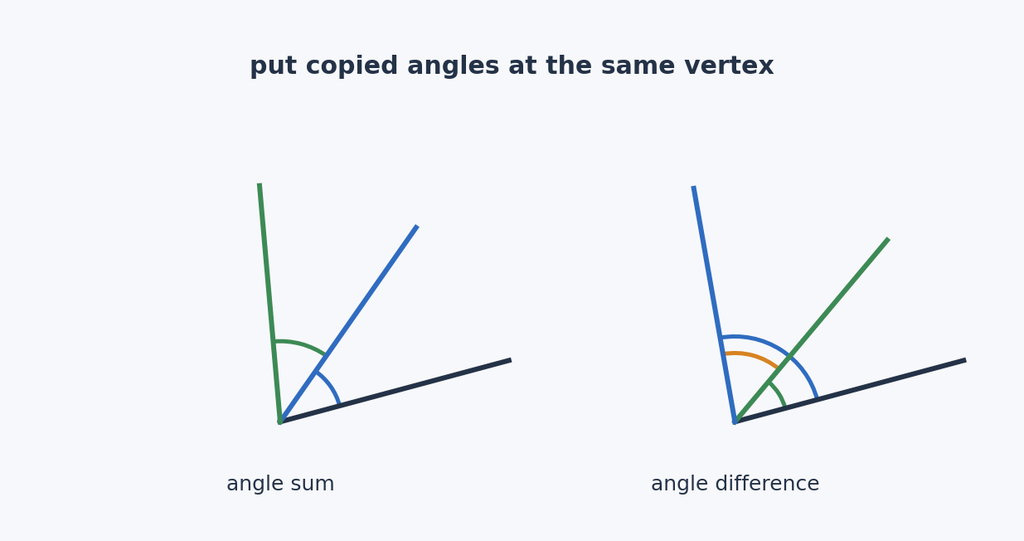

兩角和與兩角差

圖解：用同一頂點示意角和與角差，讓學生看出角度加減的位置關係。